# Big History

Prem

22 de abril de 2016

# The Universe

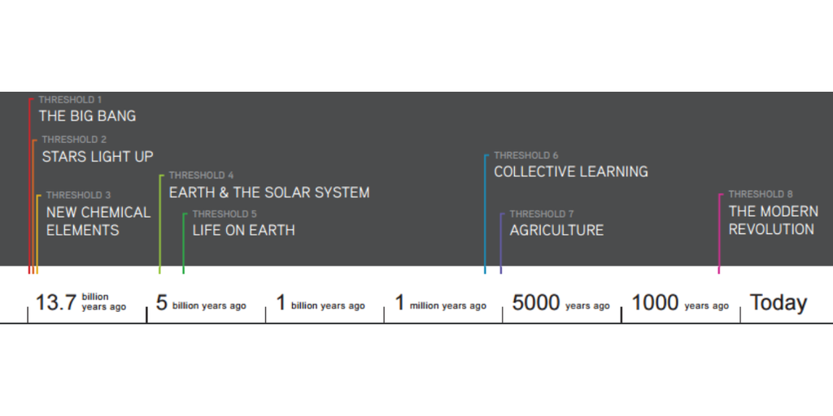

## Threshold 1: Big Bang

Big Bang

- Something out of nothing. Creates everything. Time, space, matter (electrons/protons) and energy (gravity, electromagnetisim, nuclear)
- Universe starts as hot grapefruit which expands and cools
- Matter exists as plasma of charged particles (electrons/protons), preventing light escaping, until **380,000 years later** universe cools enough to enable electrons and protons to join into atoms (H/He)
- Universe is a boring and simple mush, with uniform density, temperature and the same types of atoms floating through space until gravity…

## Threshold 2: Stars are born

How stars are born

- **200 million years after** big bang stars begin to light up our universe, creating new structures and hot-spots which aids further diversity
- Universe goes from cooling down to heating up, campfires within the antartic
- **380,000 years after** the big bang, the cold and dark universe is *filled with atoms (H/He)*, with areas of atoms which are *slightly hotter/denser* that *gravity pulls together* into clouds that *heat up* enough to create plasma centre where *protons fuse* and *huge amounts of energy* is released into the universe, lighting it up and providing the building blocks for further complexity
- **Ingredients**
  - Matter: Helium and Hydrogen atoms
  - Gravity
- **Goldilocks condition**
  - Tiny variations in the density of matter (pockets of closely packed hydrogen atoms)
    - Enables gravity to pull together atoms into increasingly denser clouds, which heat up as they do
    - Gravity magnified tiny differences, creating something new
  - Temperatures > 10 million degrees C
    - Increasing temp (3000 degrees) causes atoms to split, centre of clouds re-enter plasma stage, once heat reaches 10 million degrees, protons (H nuclei) fuse into He nuclei and release huge amounts of energy and thus creates a star
- **new complexity**
  - Hot-spots = places in the universe where there is enough energy for and matter to create more goldilocks conditions
  - New structures / scales = stars, galaxies, galaxy cluster and superclusters
    - stars =
    - galaxies = hundreds of billions of stars. There may be 100 billion galaxies in universe
    - galaxy cluster = groups of galaxies
    - super cluster = webs and chains of galaxy clusters. Beyond this gravity too weak to hold onto super-cluster, which is where hubble witnessed whole super-clusters moving apart, at that scale you see the expansion of the universe

## Threshold 3: New Chemical Elements

How stars forge matter in the universe

- The universe was relatively simple until the first stars aged and die. Not much could be made with H/Helium. Dying stars created the extremely high temperatures needed to fuse nuclei and create new elements. All elements had distinct properties and provided the raw materials for nearly endless possibillities
- The first structures to fill the galaxy were nebulae - clouds of dust and gas (H/He atoms) - which went on to collapse into stars and then galaxies 200 million years after the big bang. *Stars began to burn hydrogen* to create helium. Helium burned to create carbon. Neon, oxygen, sillicon and iron were also created *during the life of the star*. However, it is after the death of the first stars that things got interesting. The explosions that resulted from giant stars running out of fuel resulted in the creation of many of the elements. Without the death of stars, our world would not exist.
- Stars are a battle between **gravity**, trying to collapse the star, and **it’s internal furnace**, fuelled by burning atoms, that pushes against gravity to release energy. **Whenever a star runs out fuel, the furnace turns off and gravity wins, collapsing the star and re-igniting the furnance to create new fuel**
- **Ingredients**
  - Dying and aging stars
    - Large mass stars are required to reach high enough temperatures on their death beds to initiate fusion of nuclei
  - Very high temperatures
- **Goldilocks conditions**
  - Stars running out of hydrogen fuel
    - Running out of hydrogen causes the star to collapse and generate enough heat/presurre to fuse helium nuclei into carbon, this *nuclear fusion* repeats up to iron
  - Giant stars collapsing and exploding
    - If the star is large enough, it will have a final collapse as a supernovae in which most of the elements are forged and scattered throughout the universe in an explosion
- **new complexity**
  - chemistry is born
    - 92 elements. Each with its own distinct structure and properties scatter throughout space and combine with one another to form chemical compounds that interact in complex ways

### What did the stars give us?

- Large stars are hungry and continue to fuse elements until it reaches iron - **the star killer** - and resembles a layered cake. After this, a catastrophic event occurs. Without the outpouring of energy, the outer layers fall inwards, in an avalance of matter crumbling due to the pull of gravity from the dense core. The matter slams with unimaginable force into the star’s iron centre, creating new elements. These new elements bounce off of the iron core, hurtling out towards space. This is a supernova - the death of a star- and the birth of new elements.

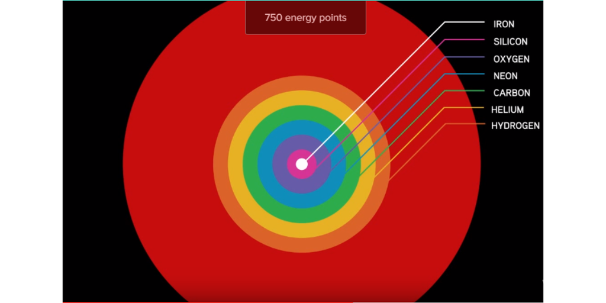

- The stars death is a run-a-away cycle, each larger element burning quicker than the one before. A star will exhuast hydrogen in a few million years, will burn helium for half a million years and, as the core continues to contract and temperature continues to rise, will burn carbon for six hundred years, oxygen for six months and silicon for one day
  - *note*: burning refers to nuclear fusion and NOT combustion
- 98% of the universe is composed of Hydrogen and Helium and 2% of the other elements. Why is this 2% a big deal? It created you, me, this computer and our world
- To create Helium you need to bang 2 protons together, that needs 10 million degrees. To create Carbon you need to bang 6 protons together at 200 million degrees. To create iron you need to smash 26 protons together, which needs temperatures of 3 billion degrees
- Remember, billions of year ago there was no gold or silver anywhere in the universe. It came from dying stars and in their cataclysmic explosion that marked the end of their lives. This is the only place where temperature get enough to fusei hydrogen nuclei together to form larger atoms. These larger heavier atoms went on to form planets like Earth and everything that isn’t cloud of gas or a star (a collapsed cloud of gas)

# Our Solar system and Earth

## Threshold 4: Earth and the Solar system

How tasty morsels of gas and rock created our home